# Nimble Model Building

2023-02-20

## Models for Malaria Programs

The framework for policy engagement is called **Adaptive Malaria Control,** a structured, iterative process that involves:

- Organizing malaria data so it can be used (and reused) for many purposes
- Conventional data analytics to identify patterns, identify data gaps, *etc.*
- Simulation-based analytics to
  - estimate the burden and averted burden of malaria
  - estimate transmission, thresholds, & the impact of interventions
  - tailor, target and estimate optimal resource allocation

## Adaptive Malaria Control

The analytical framework to support adaptive malaria control is called RAMP (**R**obust **A**nalytics for **M**alaria **P**olicy), which has some guiding principles:

- For simulation-based analytics, we need to build and analyze model *swarms* that cover the uncertainty. The models should be *realistic* enough to serve programmatic needs and facilitate communication.
- Analytics for adaptive malaria control are designed to be updated, so the framework building model swarms should make it easy to modify / extend models.
- Models should follow well-defined protocols using stable software with *version control.* The data, the software, and the protocols all need to be repeatable and modifiable.
- Models should serve many needs (*e.g.* GFATM grants, strategic planning, national targeting, support for district managers) but remain inter-operable.
- The kind of *model building* we envision involves *applying* models that have already been published, drawing on model libraries with *domain specific* model families that cover uncertainty about the *process.* We can develop new models if existing models don’t serve our needs.

## Model Building Framework

We developed flexible, modular framework for model building:

- A **Library** of domain specific model families for core dynamics
- Patch-based **Spatial Dynamics** with human travel and mobility, mosquito dispersal, & spatial heterogeneity
- Models for **Mosquito Ecology & Behavior** linking adult behaviors and aquatic population dynamics with modules for **Vector Control** and **Exogenous Forcing** by weather, land use changes, *etc.* to understand malaria as a *changing baseline* that has been *modified by control*
- **Malaria epidemiology** to quantify infection, transmission, disease & burden with utilities to **stratify** populations by age, sex, & other epidemiologically relevant traits and modules for mass treatment and health systems

## Software

The model building framework that we described above has been implemented in several inter-operable software packages:

- The core simulation software is called `exDE` and `MicroMoB`. **NOTE** development of `MicroMoB` currently lags behind `exDE`
- The extended model library is maintained locally (for now) in the `ramp_library`
- Utilities to set up and modify models are found in `mob_setup`
- Wrappers and functions that execute workflows are found in `mob_work`

## Setup

If you have a working knowledge of R and RStudio, you can follow along.

- Download the latest version of `exDE` from `github`:

```r
library(devtools)
devtools::install_github("dd-harp/exDE")
```

- You will probably need to install or update several R packages, including `deSolve`

```r
library(exDE)
library(deSolve)
```

- You will need to clone the `RAMP-Model-Library,` then source `mob_setup`

> https://github.com/dd-harp/RAMP-Model-Library.

```r
source("../mob_setup/mob_setup.R")
source_mob_setup()
```

## Demo

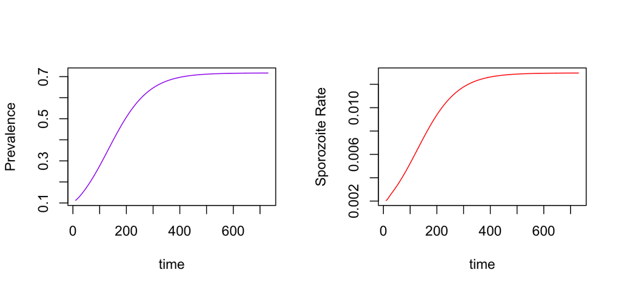

```r
ez_setup_exDE("default", Lambda = 130, H=100)->default
exDE_solve(default, Tmax=730) -> out
```

Using default options, `ez_setup_exDE` sets up a *Ross-Macdonald* model, and `exDE_solve` solves it.